# Behavioral Analysis Posner+SSVEP paradigm

[Christopher Gundlach](https://www.researchgate.net/profile/Christopher_Gundlach)

2023-03-13

# Initialisierung

**Setting up R libraries**

# Analysis of electrophysiological data (Posner Paradigma)

## subaveraged Daten werden geladen

Loading data data_in/Behavior_FFT_singletrials_cue.txt

The data has the following structure

- trialnumber = trial
- blocknumber
- trial_timing_type = 1=regular; 2=control
- cue_validity = 1=valid, 2=invalid, 3=neutral
- cue_validity_label
- cue_direction = 1=left, 2=right
- cue_direction_label
- cue_onset_fr = frame number of cue presentation
- cue_onset_t_est = onset time in ms
- cue_onset_t_meas = nan
- pre_event_type = 1=shorter, 2=longer, NaN=no event
- pre_event_onset_fr = onset frame of event
- pre_event_onset_t_est = onset time in ms
- pre_event_onset_t_meas = nan
- post_event_pos = position of post event: 1 = left, 2=right
- post_event_pos_label
- post_event_direction = direction of target (-90:90)=top;
- post_event_direction_c = category of target position: 1=top; 2=bottom
- post_event_direction_c_l = label
- post_event_dimenstion = size in degrees
- post_event_onset_fr = onset frames of event
- post_event_onset_t_est = onset times of events
- post_event_onset_t_meas = nan
- triggernum = trigger number
- pre_hit = empty=no event, TRUE=hit, 0=error, NaN=miss
- pre_RT = RT in ms
- post_hit = TRUE=hit, 0=error, NaN=miss
- post_RT = RT in ms
- subject
- FFT measures …

# Manipulation of data

long into wide format

# Illustration of Data

## Plots

1a Illustrate Data as is

- pooled across left and right side and only hits

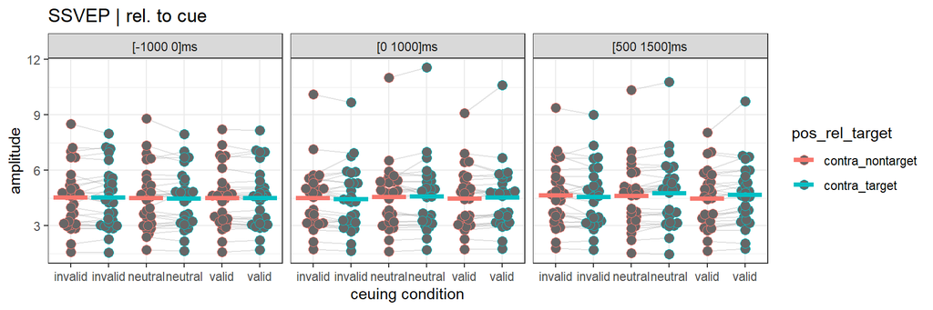

```r
# str(DATA.In_wide)
dat_plot <- DATA.In_wide %>%
  filter(post_hit == "hit") %>%
  dplyr::select(subject, trialnumber, cue_validity_label, post_event_pos_label, signal, time, amplitude, pos_rel_target)%>%
  group_by(subject, cue_validity_label, post_event_pos_label, signal, time, pos_rel_target) %>%
  dplyr::summarise(amplitude=mean(amplitude))%>%
  ungroup()%>%
  group_by(subject, cue_validity_label, signal, time, pos_rel_target) %>%
  dplyr::summarise(amplitude=mean(amplitude))%>%
  ungroup()
dat2plot <- dat_plot %>%
  filter(signal == "SSVEP")


theme_set(theme_bw())
ggplot(dat2plot, aes(x=interaction( pos_rel_target, cue_validity_label),
                              y=amplitude, fill=pos_rel_target, color = pos_rel_target,)) +
  geom_line(aes(group = interaction(subject, cue_validity_label)),alpha = 0.3, colour = "grey60") +
  geom_beeswarm(aes(color = pos_rel_target, x = interaction( pos_rel_target, cue_validity_label), group = pos_rel_target),
                cex=2, size = 3, shape=21,alpha=1,fill="grey40",shape=21)+
  stat_summary(fun=mean, aes(ymin=..y.., ymax=..y.., color =pos_rel_target), geom='errorbar', width=0.9, size=1.5) +
  facet_grid(.~time) +
  # scale_x_discrete("ceuing condition", breaks=waiver(),
  #                  labels = c("inva","lid","neut","ral","val","id")) +
  scale_x_discrete("ceuing condition", breaks=waiver(),
                   labels = c("invalid","invalid","neutral","neutral","valid","valid")) +
  ggtitle("SSVEP | rel. to cue")
```

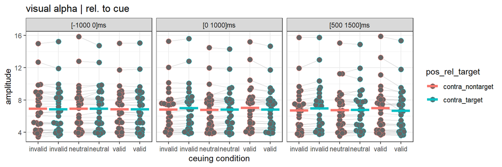

```r
dat2plot <- dat_plot %>%
  filter(signal == "visualAlpha")


theme_set(theme_bw())
ggplot(dat2plot, aes(x=interaction( pos_rel_target, cue_validity_label),
                              y=amplitude, fill=pos_rel_target, color = pos_rel_target,)) +
  geom_line(aes(group = interaction(subject, cue_validity_label)),alpha = 0.3, colour = "grey60") +
  geom_beeswarm(aes(color = pos_rel_target, x = interaction( pos_rel_target, cue_validity_label), group = pos_rel_target),
                cex=2, size = 3, shape=21,alpha=1,fill="grey40",shape=21)+
  stat_summary(fun=mean, aes(ymin=..y.., ymax=..y.., color =pos_rel_target), geom='errorbar', width=0.9, size=1.5) +
  facet_grid(.~time) +
  # scale_x_discrete("ceuing condition", breaks=waiver(),
  #                  labels = c("inva","lid","neut","ral","val","id")) +
  scale_x_discrete("ceuing condition", breaks=waiver(),
                   labels = c("invalid","invalid","neutral","neutral","valid","valid")) +
  ggtitle("visual alpha | rel. to cue")
```

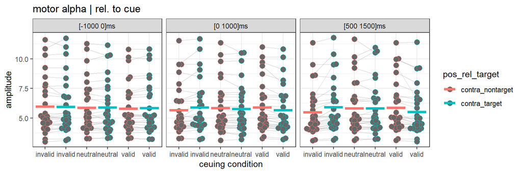

```r
dat2plot <- dat_plot %>%
  filter(signal == "motorAlpha")


theme_set(theme_bw())
ggplot(dat2plot, aes(x=interaction( pos_rel_target, cue_validity_label),
                     y=amplitude, fill=pos_rel_target, color = pos_rel_target,)) +
  geom_line(aes(group = interaction(subject, cue_validity_label)),alpha = 0.3, colour = "grey60") +
  geom_beeswarm(aes(color = pos_rel_target, x = interaction( pos_rel_target, cue_validity_label), group = pos_rel_target),
                cex=2, size = 3, shape=21,alpha=1,fill="grey40",shape=21)+
  stat_summary(fun=mean, aes(ymin=..y.., ymax=..y.., color =pos_rel_target), geom='errorbar', width=0.9, size=1.5) +
  facet_grid(.~time) +
  # scale_x_discrete("ceuing condition", breaks=waiver(),
  #                  labels = c("inva","lid","neut","ral","val","id")) +
  scale_x_discrete("ceuing condition", breaks=waiver(),
                   labels = c("invalid","invalid","neutral","neutral","valid","valid")) +
  ggtitle("motor alpha | rel. to cue")
```

1b Illustrate Data as is

- plot modulation pooled across left and right side and only hits

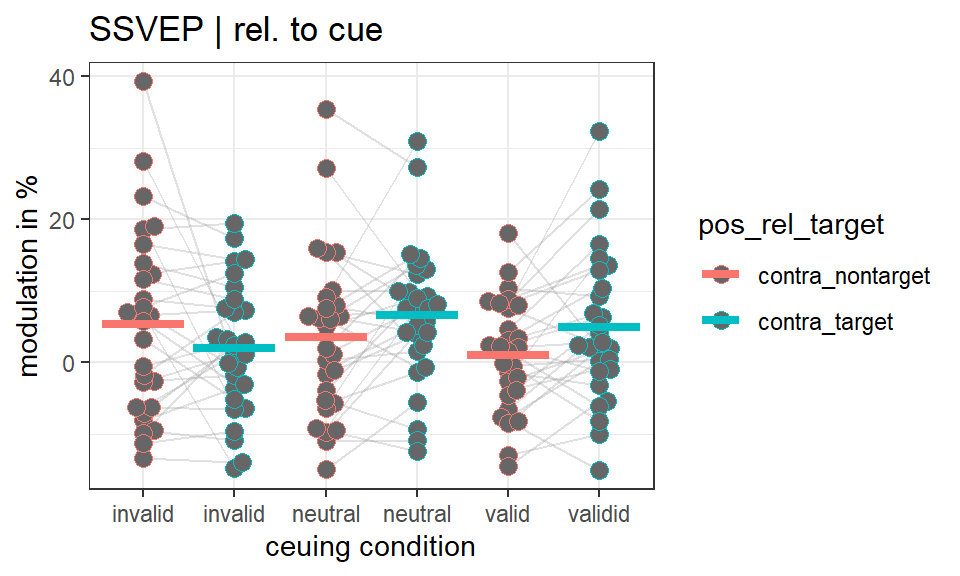

```r
# str(DATA.In_wide)
dat_plot <- DATA.In_wide %>%
  filter(post_hit == "hit") %>%
  dplyr::select(subject, trialnumber, cue_validity_label, post_event_pos_label, signal, time, amplitude, pos_rel_target)%>%
  group_by(subject, cue_validity_label, post_event_pos_label, signal, time, pos_rel_target) %>%
  dplyr::summarise(amplitude=mean(amplitude))%>%
  ungroup()%>%
  pivot_wider(names_from = "time", values_from = amplitude) %>%
  mutate(pre_to_post = ((`[500 1500]ms`/`[-1000 0]ms`)-1)*100)%>%
  # mutate(pre_to_post = `[500 1500]ms`-`[-1000 0]ms`)%>%
  pivot_longer(`[-1000 0]ms`:pre_to_post, names_to = "time", values_to = "amplitude") %>%
  group_by(subject, cue_validity_label, signal, time, pos_rel_target) %>%
  dplyr::summarise(amplitude=mean(amplitude))%>%
  ungroup()%>%
  filter(time == "pre_to_post")
dat2plot <- dat_plot %>%
  filter(signal == "SSVEP")


theme_set(theme_bw())
ggplot(dat2plot, aes(x=interaction( pos_rel_target, cue_validity_label),
                              y=amplitude, fill=pos_rel_target, color = pos_rel_target,)) +
  geom_line(aes(group = interaction(subject, cue_validity_label)),alpha = 0.3, colour = "grey60") +
  geom_beeswarm(aes(color = pos_rel_target, x = interaction( pos_rel_target, cue_validity_label), group = pos_rel_target),
                cex=2, size = 3, shape=21,alpha=1,fill="grey40",shape=21)+
  stat_summary(fun=mean, aes(ymin=..y.., ymax=..y.., color =pos_rel_target), geom='errorbar', width=0.9, size=1.5) +
  scale_x_discrete("ceuing condition", breaks=waiver(),
                   labels = c("invalid","invalid","neutral","neutral","valid","validid")) +
  ylab('modulation in %')+
  ggtitle("SSVEP | rel. to cue")
```

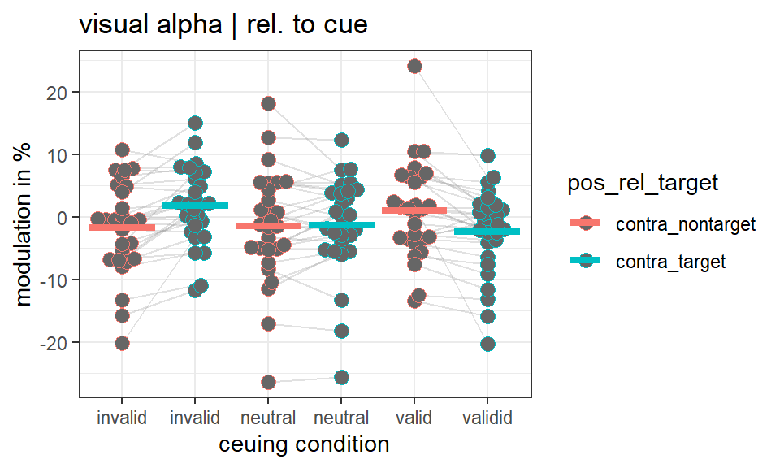

```r
dat2plot <- dat_plot %>%
  filter(signal == "visualAlpha")


theme_set(theme_bw())
ggplot(dat2plot, aes(x=interaction( pos_rel_target, cue_validity_label),
                              y=amplitude, fill=pos_rel_target, color = pos_rel_target,)) +
  geom_line(aes(group = interaction(subject, cue_validity_label)),alpha = 0.3, colour = "grey60") +
  geom_beeswarm(aes(color = pos_rel_target, x = interaction( pos_rel_target, cue_validity_label), group = pos_rel_target),
                cex=2, size = 3, shape=21,alpha=1,fill="grey40",shape=21)+
  stat_summary(fun=mean, aes(ymin=..y.., ymax=..y.., color =pos_rel_target), geom='errorbar', width=0.9, size=1.5) +
  scale_x_discrete("ceuing condition", breaks=waiver(),
                   labels = c("invalid","invalid","neutral","neutral","valid","validid")) +
   ylab('modulation in %')+
  ggtitle("visual alpha | rel. to cue")
```

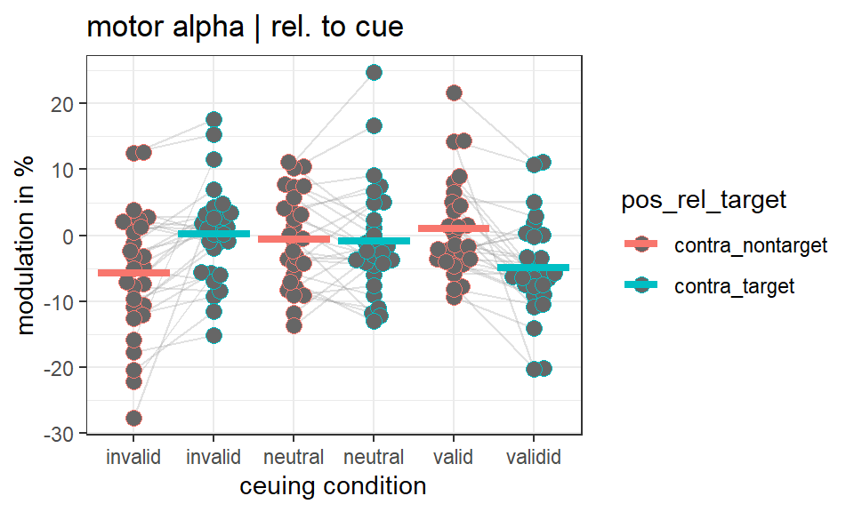

```r
dat2plot <- dat_plot %>%
  filter(signal == "motorAlpha")


theme_set(theme_bw())
ggplot(dat2plot, aes(x=interaction( pos_rel_target, cue_validity_label),
                              y=amplitude, fill=pos_rel_target, color = pos_rel_target,)) +
  geom_line(aes(group = interaction(subject, cue_validity_label)),alpha = 0.3, colour = "grey60") +
  geom_beeswarm(aes(color = pos_rel_target, x = interaction( pos_rel_target, cue_validity_label), group = pos_rel_target),
                cex=2, size = 3, shape=21,alpha=1,fill="grey40",shape=21)+
  stat_summary(fun=mean, aes(ymin=..y.., ymax=..y.., color =pos_rel_target), geom='errorbar', width=0.9, size=1.5) +
  scale_x_discrete("ceuing condition", breaks=waiver(),
                   labels = c("invalid","invalid","neutral","neutral","valid","validid")) +
  ylab('modulation in %')+
  ggtitle("motor alpha | rel. to cue")
```

1a Illustrate Data as is

- pooled across left and right side and only hits

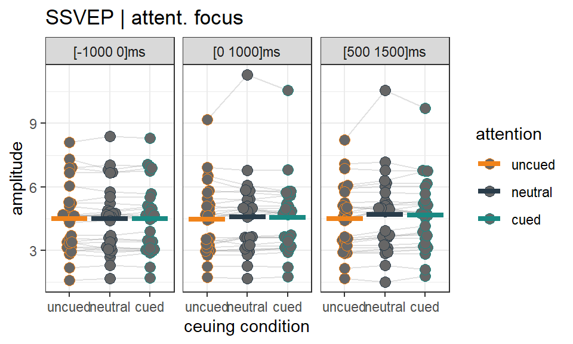

```r
# str(DATA.In_wide)
dat_plot <- DATA.In_wide %>%
  filter(post_hit == "hit") %>%
  dplyr::select(subject, trialnumber, cue_validity_label, post_event_pos_label, signal, time, amplitude, attention)%>%
  group_by(subject, post_event_pos_label, signal, time, attention) %>%
  dplyr::summarise(amplitude=mean(amplitude))%>%
  ungroup()%>%
  group_by(subject, signal, time, attention) %>%
  dplyr::summarise(amplitude=mean(amplitude))%>%
  ungroup()
dat2plot <- dat_plot %>%
  filter(signal == "SSVEP")


theme_set(theme_bw())
ggplot(dat2plot, aes(x=attention, y=amplitude, fill=attention, color = attention,)) +
  geom_line(aes(group = interaction(subject)),alpha = 0.3, colour = "grey60") +
  geom_beeswarm(aes(color = attention, x = attention, group = attention),
                cex=2, size = 3, shape=21,alpha=1,fill="grey40",shape=21)+
  stat_summary(fun=mean, aes(ymin=..y.., ymax=..y.., color =attention), geom='errorbar', width=0.9, size=1.5) +
  facet_grid(.~time) +
  scale_fill_manual(values=c("#F1831A", "#293C4A", "#198A83"))+
  scale_color_manual(values=c("#F1831A", "#293C4A", "#198A83"))+
  scale_x_discrete("ceuing condition", breaks=waiver(),
                   labels = waiver()) +
  ggtitle("SSVEP | attent. focus")
```

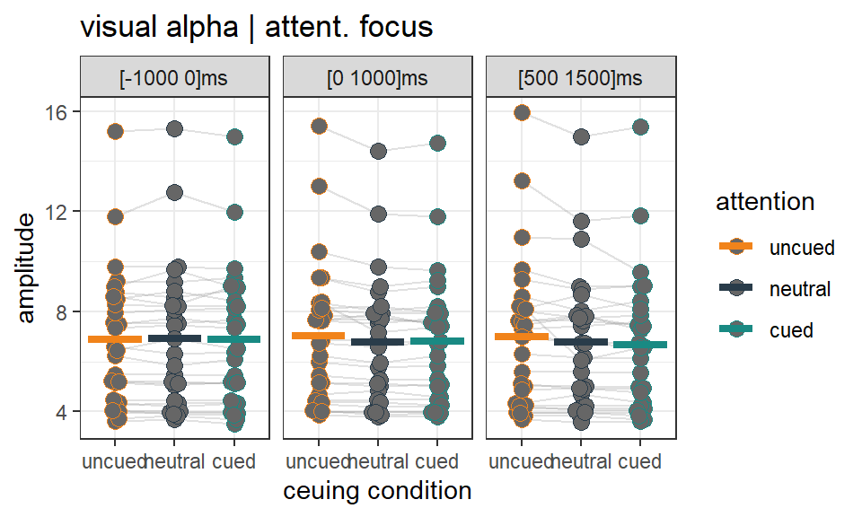

```r
dat2plot <- dat_plot %>%
  filter(signal == "visualAlpha")


theme_set(theme_bw())
ggplot(dat2plot, aes(x=attention, y=amplitude, fill=attention, color = attention,)) +
  geom_line(aes(group = interaction(subject)),alpha = 0.3, colour = "grey60") +
  geom_beeswarm(aes(color = attention, x = attention, group = attention),
                cex=2, size = 3, shape=21,alpha=1,fill="grey40",shape=21)+
  stat_summary(fun=mean, aes(ymin=..y.., ymax=..y.., color =attention), geom='errorbar', width=0.9, size=1.5) +
  facet_grid(.~time) +
  scale_fill_manual(values=c("#F1831A", "#293C4A", "#198A83"))+
  scale_color_manual(values=c("#F1831A", "#293C4A", "#198A83"))+
  scale_x_discrete("ceuing condition", breaks=waiver(),
                   labels = waiver()) +
  ggtitle("visual alpha | attent. focus")
```

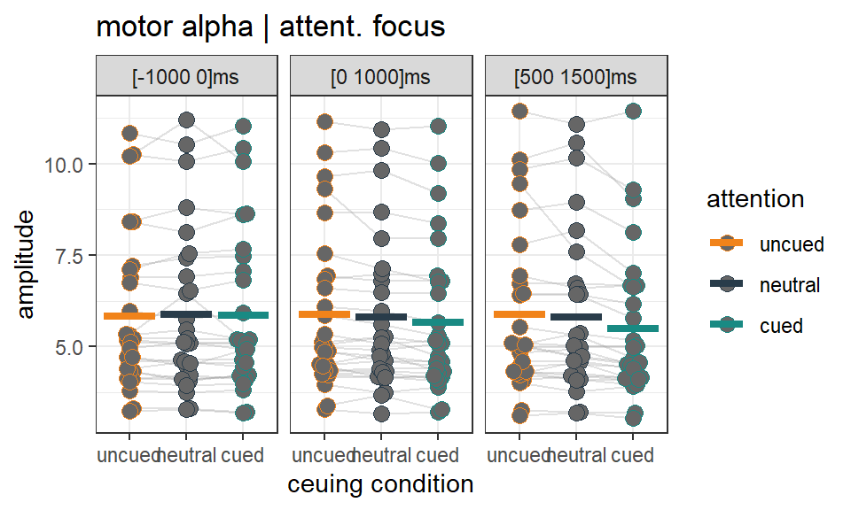

```r
dat2plot <- dat_plot %>%
  filter(signal == "motorAlpha")


theme_set(theme_bw())
ggplot(dat2plot, aes(x=attention, y=amplitude, fill=attention, color = attention,)) +
  geom_line(aes(group = interaction(subject)),alpha = 0.3, colour = "grey60") +
  geom_beeswarm(aes(color = attention, x = attention, group = attention),
                cex=2, size = 3, shape=21,alpha=1,fill="grey40",shape=21)+
  stat_summary(fun=mean, aes(ymin=..y.., ymax=..y.., color =attention), geom='errorbar', width=0.9, size=1.5) +
  facet_grid(.~time) +
  scale_fill_manual(values=c("#F1831A", "#293C4A", "#198A83"))+
  scale_color_manual(values=c("#F1831A", "#293C4A", "#198A83"))+
  scale_x_discrete("ceuing condition", breaks=waiver(),
                   labels = waiver()) +
  ggtitle("motor alpha | attent. focus")
```

1b Illustrate Data as is

- plot modulation pooled across left and right side and only hits

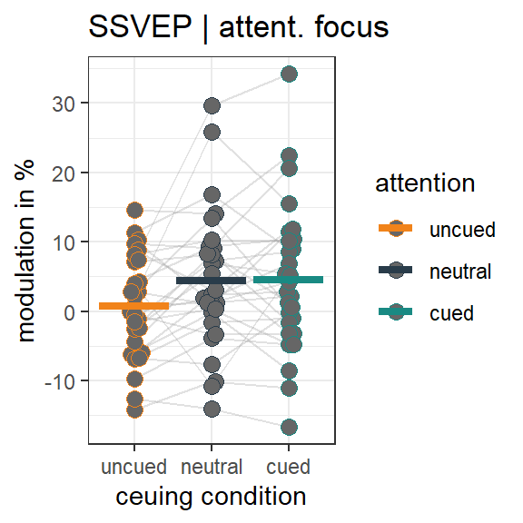

```r
# str(DATA.In_wide)
dat_plot <- DATA.In_wide %>%
  filter(post_hit == "hit") %>%
  dplyr::select(subject, trialnumber, post_event_pos_label, signal, time, amplitude, attention)%>%
  group_by(subject, post_event_pos_label, signal, time, attention) %>%
  dplyr::summarise(amplitude=mean(amplitude))%>%
  ungroup()%>%
  pivot_wider(names_from = "time", values_from = amplitude) %>%
  mutate(pre_to_post = ((`[500 1500]ms`/`[-1000 0]ms`)-1)*100)%>%
  # mutate(pre_to_post = `[500 1500]ms`-`[-1000 0]ms`)%>%
  pivot_longer(`[-1000 0]ms`:pre_to_post, names_to = "time", values_to = "amplitude") %>%
  group_by(subject, signal, time, attention) %>%
  dplyr::summarise(amplitude=mean(amplitude))%>%
  ungroup()%>%
  filter(time == "pre_to_post")
dat2plot <- dat_plot %>%
  filter(signal == "SSVEP")


theme_set(theme_bw())
ggplot(dat2plot, aes(x=attention, y=amplitude, fill=attention, color = attention,)) +
  geom_line(aes(group = subject  ),alpha = 0.3, colour = "grey60") +
  geom_beeswarm(aes(color = attention, x = attention, group = attention),
                cex=2, size = 3, shape=21,alpha=1,fill="grey40",shape=21)+
  stat_summary(fun=mean, aes(ymin=..y.., ymax=..y.., color =attention), geom='errorbar', width=0.9, size=1.5) +
  scale_fill_manual(values=c("#F1831A", "#293C4A", "#198A83"))+
  scale_color_manual(values=c("#F1831A", "#293C4A", "#198A83"))+
  scale_x_discrete("ceuing condition", breaks=waiver(),
                   labels = waiver()) +
  ylab('modulation in %')+
  ggtitle("SSVEP | attent. focus")
```

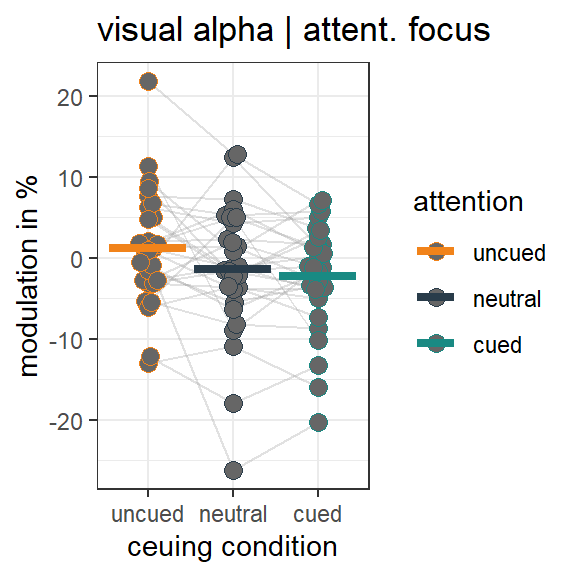

```r
dat2plot <- dat_plot %>%
  filter(signal == "visualAlpha")


theme_set(theme_bw())
ggplot(dat2plot, aes(x=attention, y=amplitude, fill=attention, color = attention,)) +
  geom_line(aes(group = subject  ),alpha = 0.3, colour = "grey60") +
  geom_beeswarm(aes(color = attention, x = attention, group = attention),
                cex=2, size = 3, shape=21,alpha=1,fill="grey40",shape=21)+
  stat_summary(fun=mean, aes(ymin=..y.., ymax=..y.., color =attention), geom='errorbar', width=0.9, size=1.5) +
  scale_fill_manual(values=c("#F1831A", "#293C4A", "#198A83"))+
  scale_color_manual(values=c("#F1831A", "#293C4A", "#198A83"))+
  scale_x_discrete("ceuing condition", breaks=waiver(),
                   labels = waiver()) +
  ylab('modulation in %')+
  ggtitle("visual alpha | attent. focus")
```

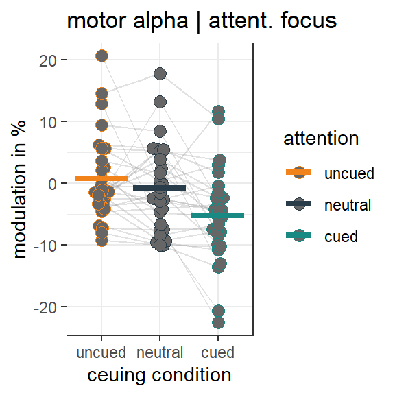

```r
dat2plot <- dat_plot %>%
  filter(signal == "motorAlpha")


theme_set(theme_bw())
ggplot(dat2plot, aes(x=attention, y=amplitude, fill=attention, color = attention,)) +
  geom_line(aes(group = subject  ),alpha = 0.3, colour = "grey60") +
  geom_beeswarm(aes(color = attention, x = attention, group = attention),
                cex=2, size = 3, shape=21,alpha=1,fill="grey40",shape=21)+
  stat_summary(fun=mean, aes(ymin=..y.., ymax=..y.., color =attention), geom='errorbar', width=0.9, size=1.5) +
  scale_fill_manual(values=c("#F1831A", "#293C4A", "#198A83"))+
  scale_color_manual(values=c("#F1831A", "#293C4A", "#198A83"))+
  scale_x_discrete("ceuing condition", breaks=waiver(),
                   labels = waiver()) +
  ylab('modulation in %')+
  ggtitle("motor alpha | attent. focus")
```

## decriptive data

### electrophysiological measures

validity x target_position

average response measures

| signal | cue_validity_label | pos_rel_target | M | SD |
| --- | --- | --- | --- | --- |
| motorAlpha | invalid | contra_nontarget | -5.767622 | 9.656 |
| motorAlpha | invalid | contra_target | 0.197405 | 7.402 |
| motorAlpha | neutral | contra_nontarget | -0.599796 | 7.061 |
| motorAlpha | neutral | contra_target | -0.883747 | 8.545 |
| motorAlpha | valid | contra_nontarget | 1.001945 | 7.361 |
| motorAlpha | valid | contra_target | -4.922634 | 7.386 |
| SSVEP | invalid | contra_nontarget | 5.362735 | 13.011 |
| SSVEP | invalid | contra_target | 2.070415 | 9.183 |
| SSVEP | neutral | contra_nontarget | 3.587750 | 11.528 |
| SSVEP | neutral | contra_target | 6.568053 | 9.754 |
| SSVEP | valid | contra_nontarget | 1.029502 | 7.770 |
| SSVEP | valid | contra_target | 5.001276 | 10.647 |
| visualAlpha | invalid | contra_nontarget | -1.744584 | 7.374 |
| visualAlpha | invalid | contra_target | 1.732357 | 6.208 |
| visualAlpha | neutral | contra_nontarget | -1.497993 | 8.933 |
| visualAlpha | neutral | contra_target | -1.331550 | 7.910 |
| visualAlpha | valid | contra_nontarget | 1.034433 | 7.681 |
| visualAlpha | valid | contra_target | -2.412490 | 6.789 |

average response measures

| signal | attention | M | SD |
| --- | --- | --- | --- |
| motorAlpha | uncued | 0.783 | 7.05694 |
| motorAlpha | neutral | -0.761 | 7.11496 |
| motorAlpha | cued | -5.185 | 7.61981 |
| SSVEP | uncued | 0.699 | 7.43293 |
| SSVEP | neutral | 4.426 | 10.05035 |
| SSVEP | cued | 4.558 | 10.67430 |
| visualAlpha | uncued | 1.170 | 7.16389 |
| visualAlpha | neutral | -1.431 | 8.29730 |
| visualAlpha | cued | -2.297 | 6.69420 |

## tests

test of general model

### ANOVA electrophysiological measures

ANOVA_RM for electrophysiological measures: meas ~ ATTENTION(cued, neutral, uncued)

```r
#ANOVAe
DATA.In_wide %>%
  filter(post_hit == "hit") %>%
  dplyr::select(subject, trialnumber, post_event_pos_label, signal, time, amplitude, attention)%>%
  group_by(subject, post_event_pos_label, signal, time, attention) %>%
  dplyr::summarise(amplitude=mean(amplitude))%>%
  ungroup()%>%
  pivot_wider(names_from = "time", values_from = amplitude) %>%
  mutate(pre_to_post = ((`[500 1500]ms`/`[-1000 0]ms`)-1)*100)%>%
  # mutate(pre_to_post = `[500 1500]ms`-`[-1000 0]ms`)%>%
  pivot_longer(`[-1000 0]ms`:pre_to_post, names_to = "time", values_to = "amplitude") %>%
  group_by(subject, signal, time, attention) %>%
  dplyr::summarise(amplitude=mean(amplitude))%>%
  ungroup()%>%
  filter(time == "pre_to_post")%>%
  group_by(signal)%>%
  nest() %>%
  mutate(stats= purrr::map(data, ~broom::tidy(
    anova(aov_ez(id="subject", dv = "amplitude", data = ., within = "attention"))
  ))) %>%
  dplyr::select(-data) %>%
  unnest()%>%
  mutate(
    `p.value` = cell_spec(ifelse(round(`p.value`,4)<.001,"< .001",round(`p.value`,4)),
                        color = ifelse(is.nan(`p.value`),"blue", ifelse(`p.value` < .05, "green", "red")),
                        bold = ifelse(is.nan(`p.value`),F, ifelse(`p.value` < .05, T,F)),
                        align = "center")
  ) %>%
  dplyr::select(signal, term, `num.Df`, `den.Df`, MSE, `statistic`, ges, `p.value`) %>%
  kable(escape = F, digits = c(3,3,3,3,3,3,3,3,3), caption = c("repeated measures ANOVA ")) %>%
  kable_styling("striped", full_width = T, bootstrap_options = c("striped", "hover", "condensed", "responsive",font_size = 8))
```

repeated measures ANOVA

| signal | term | num.Df | den.Df | MSE | statistic | ges | p.value |
| --- | --- | --- | --- | --- | --- | --- | --- |
| motorAlpha | attention | 1.981 | 53.497 | 27.417 | 9.892 | 0.112 | < .001 |
| SSVEP | attention | 1.944 | 52.475 | 28.644 | 4.829 | 0.036 | 0.0125 |
| visualAlpha | attention | 1.421 | 38.374 | 27.313 | 4.697 | 0.039 | 0.0247 |

### Post-hoc t-Tests electrophysiological measures (cued vs neutral vs uncued)

estimated marginal means | by att. focus | dv = SSVEP

| attention | emmean | SE | df | lower.CL | upper.CL |
| --- | --- | --- | --- | --- | --- |
| uncued | 0.699 | 1.794 | 41.436 | -2.922 | 4.320 |
| neutral | 4.426 | 1.794 | 41.436 | 0.805 | 8.047 |
| cued | 4.558 | 1.794 | 41.436 | 0.937 | 8.179 |

contrasts for estimated marginal means | by att. focus | dv = SSVEP | corrected: Holm

| contrast | estimate | SE | df | t.ratio | p.value | CohensD |
| --- | --- | --- | --- | --- | --- | --- |
| uncued - neutral | -3.728 | 1.41 | 54 | -2.644 | 0.0251 | -0.356 |
| uncued - cued | -3.859 | 1.41 | 54 | -2.737 | 0.0251 | -0.369 |
| neutral - cued | -0.132 | 1.41 | 54 | -0.093 | 0.926 | -0.013 |

estimated marginal means | by att. focus | dv = visual alpha

| attention | emmean | SE | df | lower.CL | upper.CL |
| --- | --- | --- | --- | --- | --- |
| uncued | 1.170 | 1.401 | 44.085 | -1.654 | 3.994 |
| neutral | -1.431 | 1.401 | 44.085 | -4.255 | 1.394 |
| cued | -2.297 | 1.401 | 44.085 | -5.122 | 0.527 |

contrasts for estimated marginal means | by att. focus | dv = visual alpha | corrected: Holm

| contrast | estimate | SE | df | t.ratio | p.value | CohensD |
| --- | --- | --- | --- | --- | --- | --- |
| uncued - neutral | 2.601 | 1.177 | 54 | 2.209 | 0.0629 | 0.298 |
| uncued - cued | 3.467 | 1.177 | 54 | 2.945 | 0.0143 | 0.397 |
| neutral - cued | 0.867 | 1.177 | 54 | 0.736 | 0.4649 | 0.099 |

estimated marginal means | by att. focus | dv = motor alpha

| attention | emmean | SE | df | lower.CL | upper.CL |
| --- | --- | --- | --- | --- | --- |
| uncued | 0.783 | 1.374 | 55.023 | -1.970 | 3.535 |
| neutral | -0.761 | 1.374 | 55.023 | -3.513 | 1.992 |
| cued | -5.185 | 1.374 | 55.023 | -7.938 | -2.433 |

contrasts for estimated marginal means | by att. focus | dv = motor alpha | corrected: Holm

| contrast | estimate | SE | df | t.ratio | p.value | CohensD |
| --- | --- | --- | --- | --- | --- | --- |
| uncued - neutral | 1.543 | 1.393 | 54 | 1.108 | 0.2728 | 0.149 |
| uncued - cued | 5.968 | 1.393 | 54 | 4.285 | < .001 | 0.578 |
| neutral - cued | 4.424 | 1.393 | 54 | 3.177 | 0.0049 | 0.428 |

## Additional models

### linear mixed models SSVEP

1. **estimating model**

linear mixed model of standard effects based on averaged data

testing **SSVEP ~ Validity * Position + ( 1 | subjects)**

SSVEP | fixed effects | stepwise elimination

|  | eliminated factor | Eliminated | Sum Sq | Mean Sq | NumDF | DenDF | F value | Pr(>F) |
| --- | --- | --- | --- | --- | --- | --- | --- | --- |
| cue_validity_label:pos_rel_target | cue_validity_label:pos_rel_target | 0 | 434.447 | 217.224 | 2 | 135 | 4.164 | 0.0176 |

2. model description of best model
   - Best model is lmerTest::lmer, amplitude ~ cue_validity_label * pos_rel_target + (1 | subject), lmer_model_data, TRUE

```r
model2test = best_model

## validity
anova_lsmeans_c <- lsmeans(model2test, c("cue_validity_label"))
```

```
## NOTE: Results may be misleading due to involvement in interactions
```

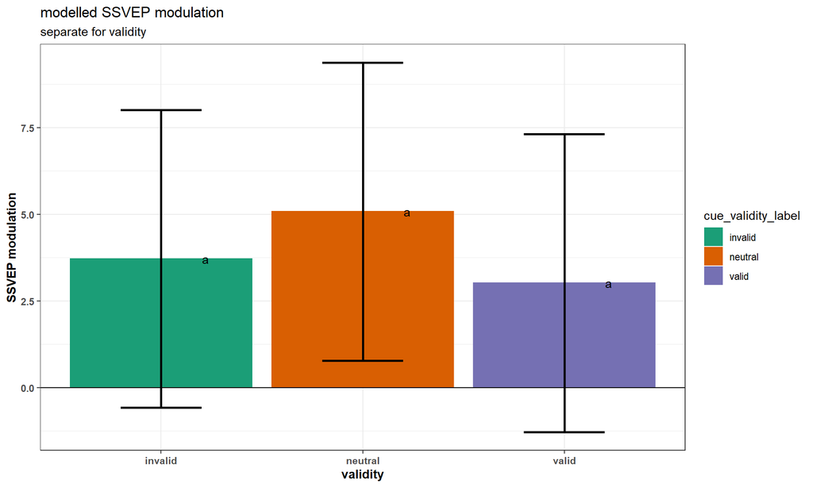

```r
CLD_obj = cld(anova_lsmeans_c,
          alpha=0.05,
          Letters=letters,      ### Use lower-case letters for .group
          adjust="holm")
CLD_obj$.group=gsub(" ", "", CLD_obj$.group)

ggplot(CLD_obj, aes(x = cue_validity_label , y = lsmean, color = cue_validity_label , fill = cue_validity_label , label = .group)) +
  stat_summary(fun.data = mean_se, geom = "bar", position = "dodge") +
  geom_hline(yintercept=0, show.legend = FALSE) +
  geom_errorbar(aes(ymin = lower.CL, ymax = upper.CL), width=.4, size=.9, position = position_dodge(0.4),color = "black") +
  theme_bw() +
  theme(axis.title = element_text(face = "bold"), axis.text = element_text(face = "bold"),plot.caption = element_text(hjust = 0)) +
  ylab("SSVEP modulation") +
  ggtitle("modelled SSVEP modulation",
           subtitle="separate for validity") +
  scale_x_discrete("validity") +
  # ggplot2::labs(caption  = paste0("\nMeans sharing a letter are ",
  #                        "not significantly different.",
  #                        "(holm corrected comparisons).")), hjust=0.5) +
  geom_text(nudge_x = c(+0.22), color   = "black") +
  # geom_text(nudge_x = c(0, -0),
  #           nudge_y = c(26.7,  26.7),
  #           color   = "black")+
  scale_fill_brewer(palette = "Dark2")+
  scale_color_brewer(palette = "Dark2")
```

```r
## position
anova_lsmeans_c <- lsmeans(model2test, c("pos_rel_target"))
```

```
## NOTE: Results may be misleading due to involvement in interactions
```

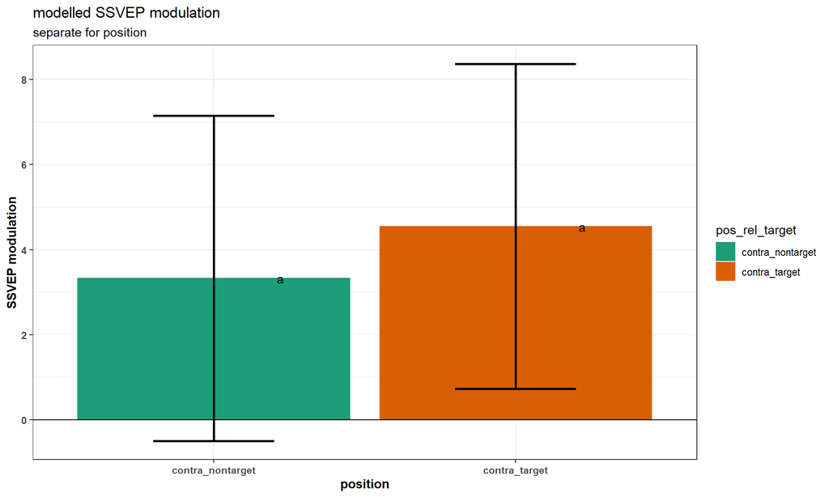

```r
CLD_obj = cld(anova_lsmeans_c,
          alpha=0.05,
          Letters=letters,      ### Use lower-case letters for .group
          adjust="holm")
CLD_obj$.group=gsub(" ", "", CLD_obj$.group)

ggplot(CLD_obj, aes(x = pos_rel_target, y = lsmean, color = pos_rel_target, fill = pos_rel_target, label = .group)) +
  stat_summary(fun.data = mean_se, geom = "bar", position = "dodge") +
  geom_hline(yintercept=0, show.legend = FALSE) +
  geom_errorbar(aes(ymin = lower.CL, ymax = upper.CL), width=.4, size=.9, position = position_dodge(0.4),color = "black") +
  theme_bw() +
  theme(axis.title = element_text(face = "bold"), axis.text = element_text(face = "bold"),plot.caption = element_text(hjust = 0)) +
  ylab("SSVEP modulation") +
  ggtitle("modelled SSVEP modulation",
           subtitle="separate for position") +
  scale_x_discrete("position") +
  # labs(caption  = paste0("\nMeans sharing a letter are ",
  #                        "not significantly different.",
  #                        "(holm corrected comparisons)."), hjust=0.5) +
  geom_text(nudge_x = c(+0.22), color   = "black") +
  # geom_text(nudge_x = c(0, -0),
  #           nudge_y = c(26.7,  26.7),
  #           color   = "black")+
  scale_fill_brewer(palette = "Dark2")+
  scale_color_brewer(palette = "Dark2")
```

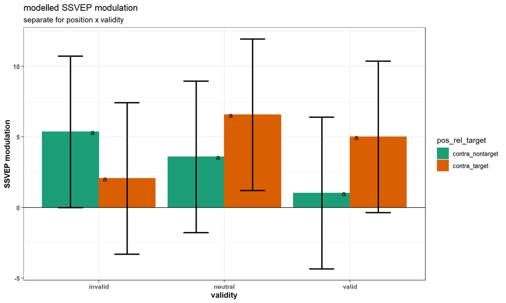

```r
## Validiaet X Seite
anova_lsmeans_c <- lsmeans(model2test, c("pos_rel_target","cue_validity_label"))
CLD_obj = cld(anova_lsmeans_c,
          alpha=0.05,
          Letters=letters,      ### Use lower-case letters for .group
          adjust="holm")
CLD_obj$.group=gsub(" ", "", CLD_obj$.group)

ggplot(CLD_obj, aes(x = cue_validity_label, y = lsmean, color = pos_rel_target, fill = pos_rel_target, label = .group)) +
  stat_summary(fun.data = mean_se, geom = "bar", position = "dodge") +
  geom_hline(yintercept=0, show.legend = FALSE) +
  geom_errorbar(aes(ymin = lower.CL, ymax = upper.CL), width=.4, size=.9, position = position_dodge(0.9),color = "black") +
  theme_bw() +
  theme(axis.title = element_text(face = "bold"), axis.text = element_text(face = "bold"),plot.caption = element_text(hjust = 0)) +
  ylab("SSVEP modulation") +
  ggtitle("modelled SSVEP modulation",
           subtitle="separate for position x validity") +
  scale_x_discrete("validity") +
  # labs(caption  = paste0("\nMeans sharing a letter are ",
  #                        "not significantly different.",
  #                        "(holm corrected comparisons)."), hjust=0.5) +
  geom_text(nudge_x = c(-0.05, 0.05), color   = "black") +
  # geom_text(nudge_x = c(0.22, -0.22, 0.22, -0.22),
  #           nudge_y = c(26.7,  26.7,26.7,  26.7),
  #           color   = "black")+
  scale_fill_brewer(palette = "Dark2")+
  scale_color_brewer(palette = "Dark2")
```

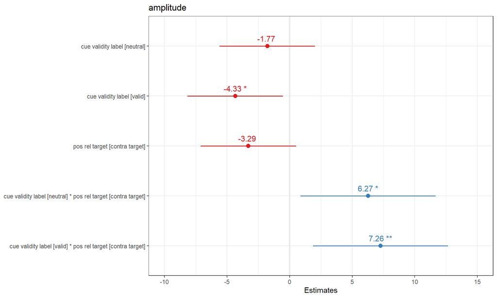

```r
plot_model(model2test, bpe.style = "dot",show.values = TRUE)
```

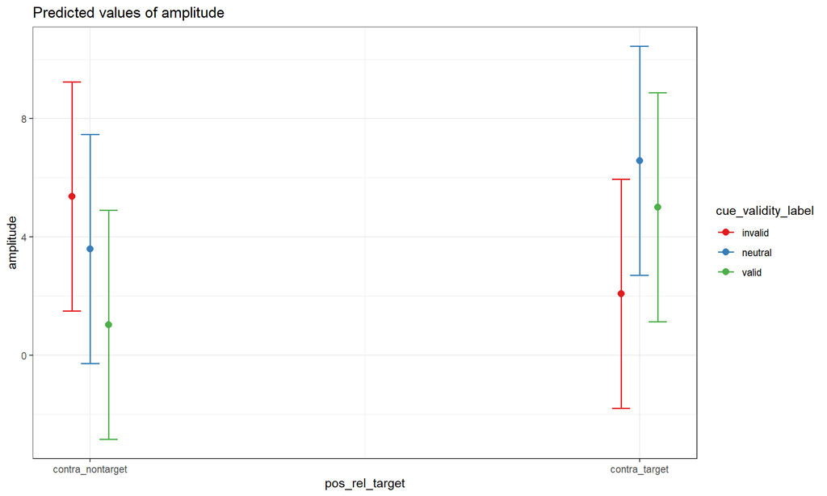

```r
plot_model(model2test, type = "pred", terms = c("pos_rel_target","cue_validity_label"))
```

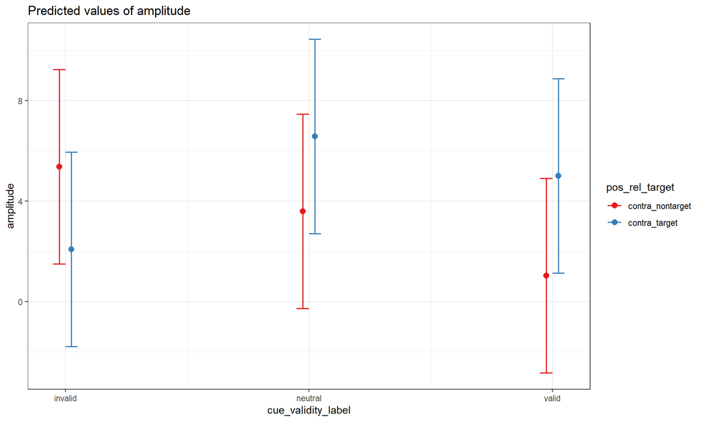

```r
plot_model(model2test, type = "pred", terms = c("cue_validity_label","pos_rel_target"))
```

### linear mixed models visual alpha

1. **estimating model**

linear mixed model of standard effects based on averaged data

testing **visual alpha ~ Validity * Position + ( 1 | subjects)**

visual Alpha | fixed effects | stepwise elimination

|  | eliminated factor | Eliminated | Sum Sq | Mean Sq | NumDF | DenDF | F value | Pr(>F) |
| --- | --- | --- | --- | --- | --- | --- | --- | --- |
| cue_validity_label:pos_rel_target | cue_validity_label:pos_rel_target | 0 | 335.793 | 167.897 | 2 | 135 | 9.23 | < .001 |

2. model description of best model
   - Best model is lmerTest::lmer, amplitude ~ cue_validity_label * pos_rel_target + (1 | subject), lmer_model_data, TRUE

```r
model2test = best_model

## validity
anova_lsmeans_c <- lsmeans(model2test, c("cue_validity_label"))
```

```
## NOTE: Results may be misleading due to involvement in interactions
```

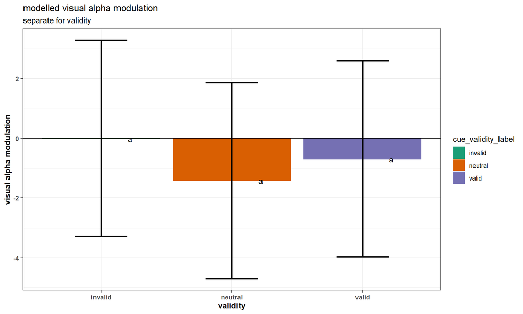

```r
CLD_obj = cld(anova_lsmeans_c,
          alpha=0.05,
          Letters=letters,      ### Use lower-case letters for .group
          adjust="holm")
CLD_obj$.group=gsub(" ", "", CLD_obj$.group)

ggplot(CLD_obj, aes(x = cue_validity_label , y = lsmean, color = cue_validity_label , fill = cue_validity_label , label = .group)) +
  stat_summary(fun.data = mean_se, geom = "bar", position = "dodge") +
  geom_hline(yintercept=0, show.legend = FALSE) +
  geom_errorbar(aes(ymin = lower.CL, ymax = upper.CL), width=.4, size=.9, position = position_dodge(0.4),color = "black") +
  theme_bw() +
  theme(axis.title = element_text(face = "bold"), axis.text = element_text(face = "bold"),plot.caption = element_text(hjust = 0)) +
  ylab("visual alpha modulation") +
  ggtitle("modelled visual alpha modulation",
           subtitle="separate for validity") +
  scale_x_discrete("validity") +
  # ggplot2::labs(caption  = paste0("\nMeans sharing a letter are ",
  #                        "not significantly different.",
  #                        "(holm corrected comparisons).")), hjust=0.5) +
  geom_text(nudge_x = c(+0.22), color   = "black") +
  scale_fill_brewer(palette = "Dark2")+
  scale_color_brewer(palette = "Dark2")
```

```r
## position
anova_lsmeans_c <- lsmeans(model2test, c("pos_rel_target"))
```

```
## NOTE: Results may be misleading due to involvement in interactions
```

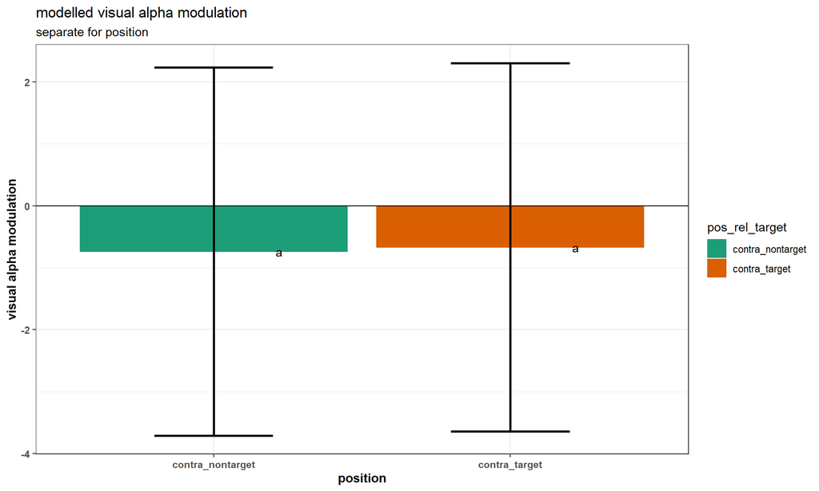

```r
CLD_obj = cld(anova_lsmeans_c,
          alpha=0.05,
          Letters=letters,      ### Use lower-case letters for .group
          adjust="holm")
CLD_obj$.group=gsub(" ", "", CLD_obj$.group)

ggplot(CLD_obj, aes(x = pos_rel_target, y = lsmean, color = pos_rel_target, fill = pos_rel_target, label = .group)) +
  stat_summary(fun.data = mean_se, geom = "bar", position = "dodge") +
  geom_hline(yintercept=0, show.legend = FALSE) +
  geom_errorbar(aes(ymin = lower.CL, ymax = upper.CL), width=.4, size=.9, position = position_dodge(0.4),color = "black") +
  theme_bw() +
  theme(axis.title = element_text(face = "bold"), axis.text = element_text(face = "bold"),plot.caption = element_text(hjust = 0)) +
  ylab("visual alpha modulation") +
  ggtitle("modelled visual alpha modulation",
           subtitle="separate for position") +
  scale_x_discrete("position") +
  # labs(caption  = paste0("\nMeans sharing a letter are ",
  #                        "not significantly different.",
  #                        "(holm corrected comparisons)."), hjust=0.5) +
  geom_text(nudge_x = c(+0.22), color   = "black") +
  scale_fill_brewer(palette = "Dark2")+
  scale_color_brewer(palette = "Dark2")
```

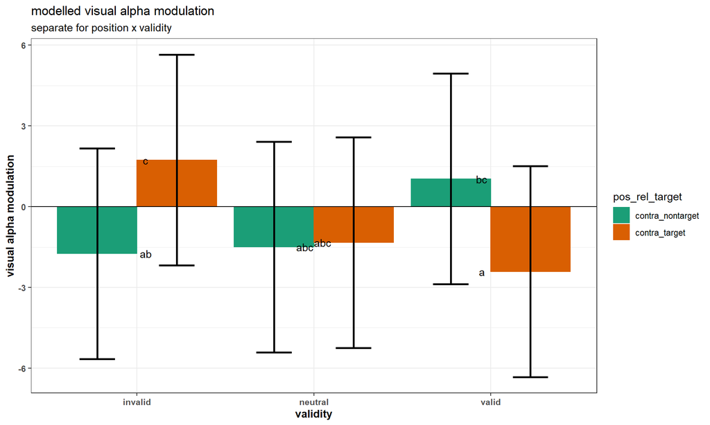

```r
## Validiaet X Seite
anova_lsmeans_c <- lsmeans(model2test, c("pos_rel_target","cue_validity_label"))
CLD_obj = cld(anova_lsmeans_c,
          alpha=0.05,
          Letters=letters,      ### Use lower-case letters for .group
          adjust="holm")
CLD_obj$.group=gsub(" ", "", CLD_obj$.group)

ggplot(CLD_obj, aes(x = cue_validity_label, y = lsmean, color = pos_rel_target, fill = pos_rel_target, label = .group)) +
  stat_summary(fun.data = mean_se, geom = "bar", position = "dodge") +
  geom_hline(yintercept=0, show.legend = FALSE) +
  geom_errorbar(aes(ymin = lower.CL, ymax = upper.CL), width=.4, size=.9, position = position_dodge(0.9),color = "black") +
  theme_bw() +
  theme(axis.title = element_text(face = "bold"), axis.text = element_text(face = "bold"),plot.caption = element_text(hjust = 0)) +
  ylab("visual alpha modulation") +
  ggtitle("modelled visual alpha modulation",
           subtitle="separate for position x validity") +
  scale_x_discrete("validity") +
  # labs(caption  = paste0("\nMeans sharing a letter are ",
  #                        "not significantly different.",
  #                        "(holm corrected comparisons)."), hjust=0.5) +
  geom_text(nudge_x = c(-0.05, 0.05), color   = "black") +
  scale_fill_brewer(palette = "Dark2")+
  scale_color_brewer(palette = "Dark2")
```

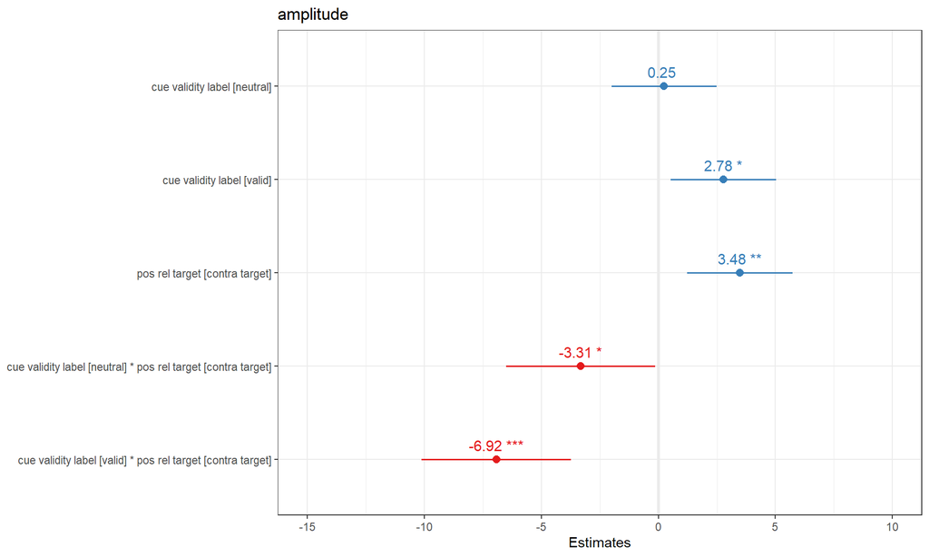

```r
plot_model(model2test, bpe.style = "dot",show.values = TRUE)
```

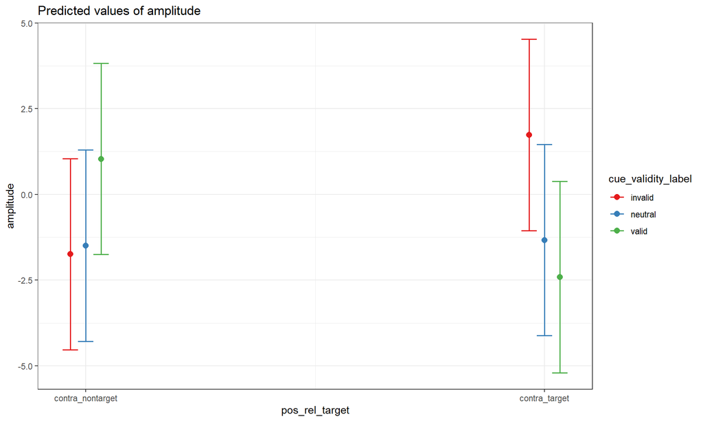

```r
plot_model(model2test, type = "pred", terms = c("pos_rel_target","cue_validity_label"))
```

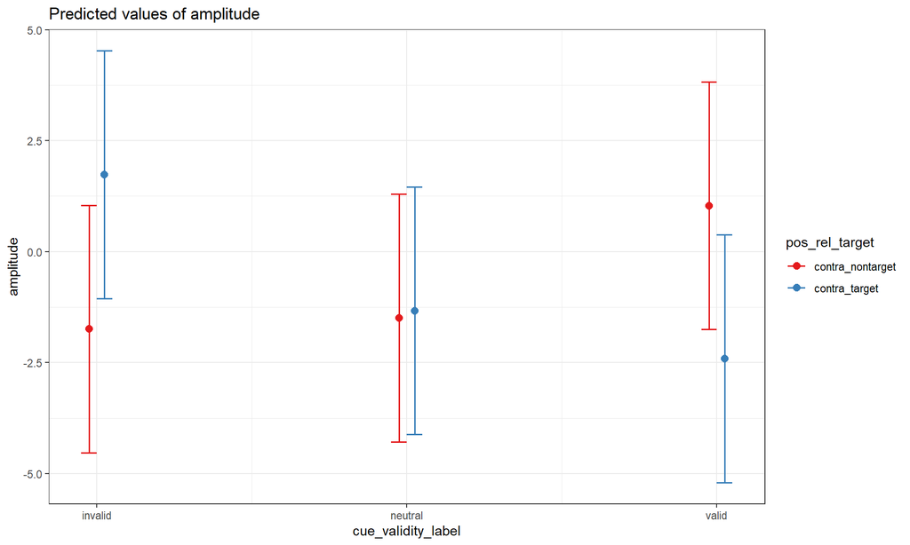

```r
plot_model(model2test, type = "pred", terms = c("cue_validity_label","pos_rel_target"))
```

### linear mixed models motor alpha

1. **estimating model**

linear mixed model of standard effects based on averaged data

testing **motor alpha ~ Validity * position + ( 1 | subjects)**

motor Alpha | fixed effects | stepwise elimination

|  | eliminated factor | Eliminated | Sum Sq | Mean Sq | NumDF | DenDF | F value | Pr(>F) |
| --- | --- | --- | --- | --- | --- | --- | --- | --- |
| cue_validity_label:pos_rel_target | cue_validity_label:pos_rel_target | 0 | 990.403 | 495.201 | 2 | 135 | 15.097 | < .001 |

2. model description of best model
   - Best model is lmerTest::lmer, amplitude ~ cue_validity_label * pos_rel_target + (1 | subject), lmer_model_data, TRUE

```r
model2test = best_model

## validity
anova_lsmeans_c <- lsmeans(model2test, c("cue_validity_label"))
```

```
## NOTE: Results may be misleading due to involvement in interactions
```

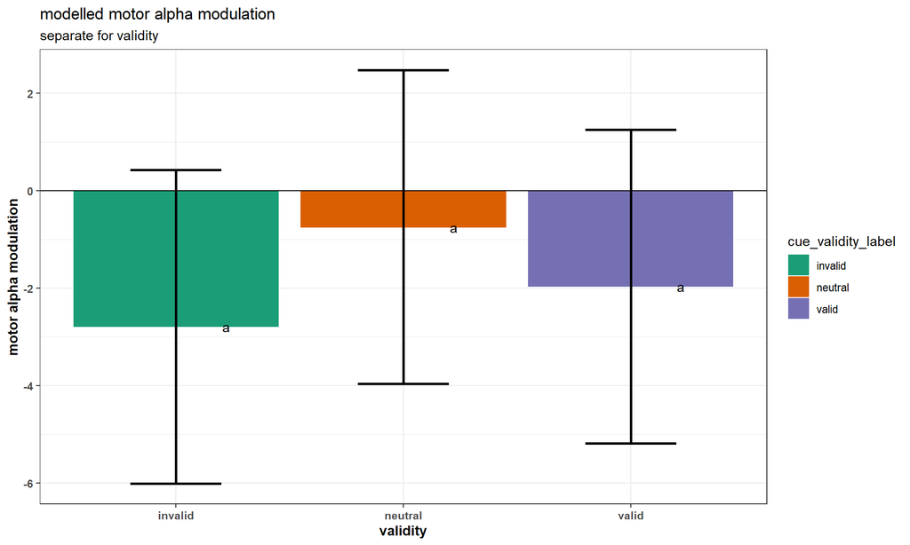

```r
CLD_obj = cld(anova_lsmeans_c,
          alpha=0.05,
          Letters=letters,      ### Use lower-case letters for .group
          adjust="holm")
CLD_obj$.group=gsub(" ", "", CLD_obj$.group)

ggplot(CLD_obj, aes(x = cue_validity_label , y = lsmean, color = cue_validity_label , fill = cue_validity_label , label = .group)) +
  stat_summary(fun.data = mean_se, geom = "bar", position = "dodge") +
  geom_hline(yintercept=0, show.legend = FALSE) +
  geom_errorbar(aes(ymin = lower.CL, ymax = upper.CL), width=.4, size=.9, position = position_dodge(0.4),color = "black") +
  theme_bw() +
  theme(axis.title = element_text(face = "bold"), axis.text = element_text(face = "bold"),plot.caption = element_text(hjust = 0)) +
  ylab("motor alpha modulation") +
  ggtitle("modelled motor alpha modulation",
           subtitle="separate for validity") +
  scale_x_discrete("validity") +
  # ggplot2::labs(caption  = paste0("\nMeans sharing a letter are ",
  #                        "not significantly different.",
  #                        "(holm corrected comparisons).")), hjust=0.5) +
  geom_text(nudge_x = c(+0.22), color   = "black") +
  scale_fill_brewer(palette = "Dark2")+
  scale_color_brewer(palette = "Dark2")
```

```r
## position
anova_lsmeans_c <- lsmeans(model2test, c("pos_rel_target"))
```

```
## NOTE: Results may be misleading due to involvement in interactions
```

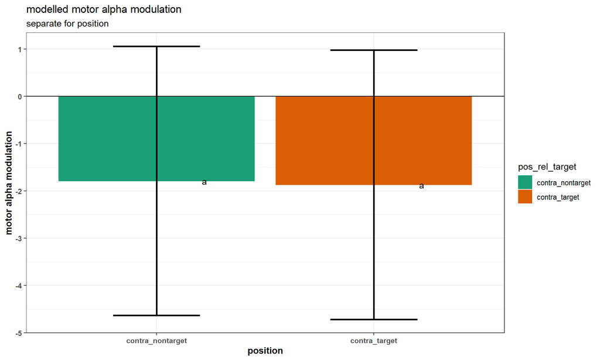

```r
CLD_obj = cld(anova_lsmeans_c,
          alpha=0.05,
          Letters=letters,      ### Use lower-case letters for .group
          adjust="holm")
CLD_obj$.group=gsub(" ", "", CLD_obj$.group)

ggplot(CLD_obj, aes(x = pos_rel_target, y = lsmean, color = pos_rel_target, fill = pos_rel_target, label = .group)) +
  stat_summary(fun.data = mean_se, geom = "bar", position = "dodge") +
  geom_hline(yintercept=0, show.legend = FALSE) +
  geom_errorbar(aes(ymin = lower.CL, ymax = upper.CL), width=.4, size=.9, position = position_dodge(0.4),color = "black") +
  theme_bw() +
  theme(axis.title = element_text(face = "bold"), axis.text = element_text(face = "bold"),plot.caption = element_text(hjust = 0)) +
  ylab("motor alpha modulation") +
  ggtitle("modelled motor alpha modulation",
           subtitle="separate for position") +
  scale_x_discrete("position") +
  # labs(caption  = paste0("\nMeans sharing a letter are ",
  #                        "not significantly different.",
  #                        "(holm corrected comparisons)."), hjust=0.5) +
  geom_text(nudge_x = c(+0.22), color   = "black") +
  scale_fill_brewer(palette = "Dark2")+
  scale_color_brewer(palette = "Dark2")
```

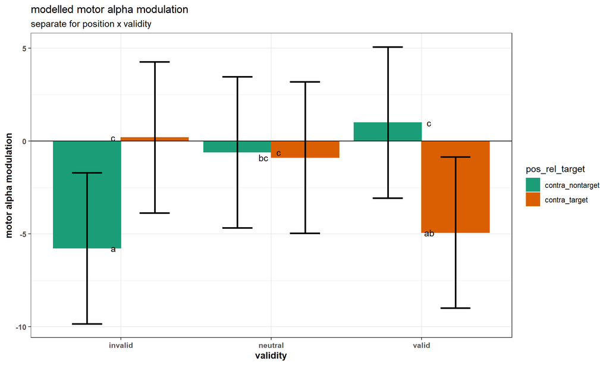

```r
## Validiaet X Seite
anova_lsmeans_c <- lsmeans(model2test, c("pos_rel_target","cue_validity_label"))
CLD_obj = cld(anova_lsmeans_c,
          alpha=0.05,
          Letters=letters,      ### Use lower-case letters for .group
          adjust="holm")
CLD_obj$.group=gsub(" ", "", CLD_obj$.group)

ggplot(CLD_obj, aes(x = cue_validity_label, y = lsmean, color = pos_rel_target, fill = pos_rel_target, label = .group)) +
  stat_summary(fun.data = mean_se, geom = "bar", position = "dodge") +
  geom_hline(yintercept=0, show.legend = FALSE) +
  geom_errorbar(aes(ymin = lower.CL, ymax = upper.CL), width=.4, size=.9, position = position_dodge(0.9),color = "black") +
  theme_bw() +
  theme(axis.title = element_text(face = "bold"), axis.text = element_text(face = "bold"),plot.caption = element_text(hjust = 0)) +
  ylab("motor alpha modulation") +
  ggtitle("modelled motor alpha modulation",
           subtitle="separate for position x validity") +
  scale_x_discrete("validity") +
  # labs(caption  = paste0("\nMeans sharing a letter are ",
  #                        "not significantly different.",
  #                        "(holm corrected comparisons)."), hjust=0.5) +
  geom_text(nudge_x = c(-0.05, 0.05) , color   = "black") +
  scale_fill_brewer(palette = "Dark2")+
  scale_color_brewer(palette = "Dark2")
```

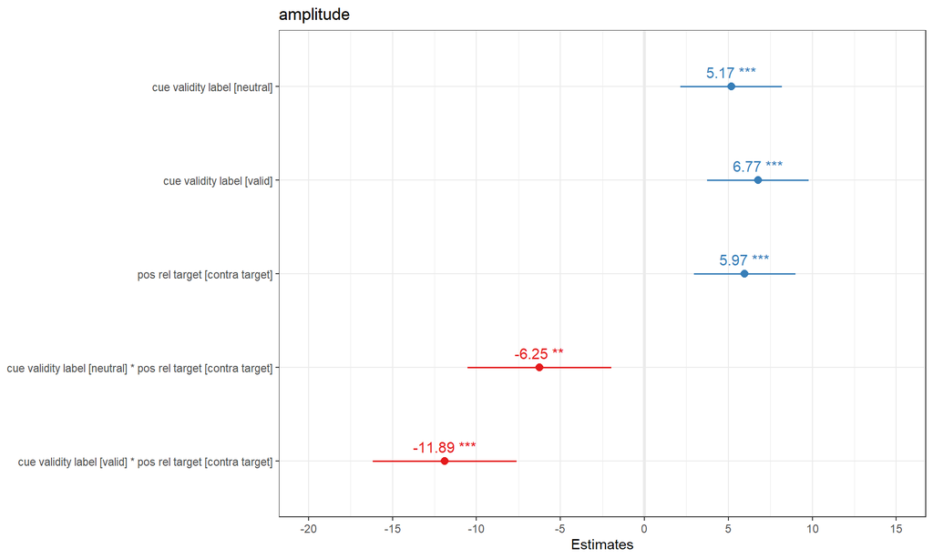

```r
plot_model(model2test, bpe.style = "dot",show.values = TRUE)
```

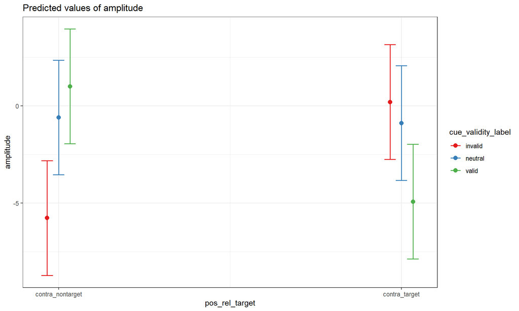

```r
plot_model(model2test, type = "pred", terms = c("pos_rel_target","cue_validity_label"))
```

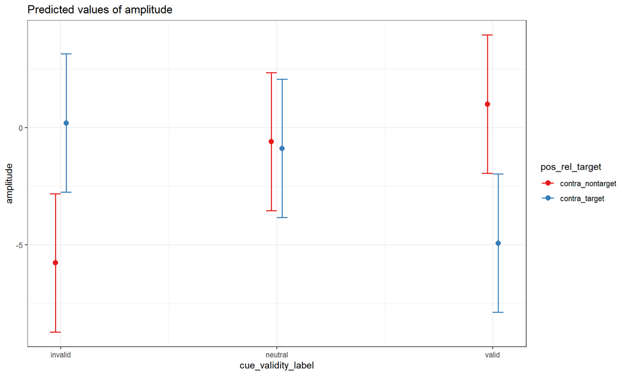

```r
plot_model(model2test, type = "pred", terms = c("cue_validity_label","pos_rel_target"))
```

### linear mixed models SSVEP II

1. **estimating model**

linear mixed model of standard effects based on single trial data

testing **SSVEP ~ Validity * position + ( 1 | subjects)**

SSVEP | fixed effects | stepwise elimination

|  | eliminated factor | Eliminated | Sum Sq | Mean Sq | NumDF | DenDF | F value | Pr(>F) |
| --- | --- | --- | --- | --- | --- | --- | --- | --- |
| cue_validity_label:pos_rel_target | cue_validity_label:pos_rel_target | 0 | 85.655 | 42.827 | 2 | 20623.6 | 4.129 | 0.0161 |

2. model description of best model
   - Best model is **lmerTest::lmer, amplitude ~ cue_validity_label * pos_rel_target + (1 | subject), lmer_model_data, TRUE**

```r
model2test = best_model
model2test = lmer_model_fit

## validity
anova_lsmeans_c <- lsmeans(model2test, c("cue_validity_label"))
```

[output not shown]

[output not shown]

```
## NOTE: Results may be misleading due to involvement in interactions
```

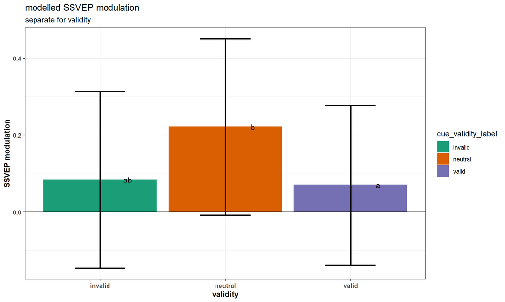

```r
CLD_obj = cld(anova_lsmeans_c,
          alpha=0.05,
          Letters=letters,      ### Use lower-case letters for .group
          adjust="holm")
CLD_obj$.group=gsub(" ", "", CLD_obj$.group)

ggplot(CLD_obj, aes(x = cue_validity_label , y = lsmean, color = cue_validity_label , fill = cue_validity_label , label = .group)) +
  stat_summary(fun.data = mean_se, geom = "bar", position = "dodge") +
  geom_hline(yintercept=0, show.legend = FALSE) +
  geom_errorbar(aes(ymin = asymp.LCL, ymax = asymp.UCL), width=.4, size=.9, position = position_dodge(0.4),color = "black") +
  theme_bw() +
  theme(axis.title = element_text(face = "bold"), axis.text = element_text(face = "bold"),plot.caption = element_text(hjust = 0)) +
  ylab("SSVEP modulation") +
  ggtitle("modelled SSVEP modulation",
           subtitle="separate for validity") +
  scale_x_discrete("validity") +
  # ggplot2::labs(caption  = paste0("\nMeans sharing a letter are ",
  #                        "not significantly different.",
  #                        "(holm corrected comparisons).")), hjust=0.5) +
  geom_text(nudge_x = c(+0.22), color   = "black") +
  scale_fill_brewer(palette = "Dark2")+
  scale_color_brewer(palette = "Dark2")
```

```r
## position
anova_lsmeans_c <- lsmeans(model2test, c("pos_rel_target"))
```

[output not shown]

[output not shown]

```
## NOTE: Results may be misleading due to involvement in interactions
```

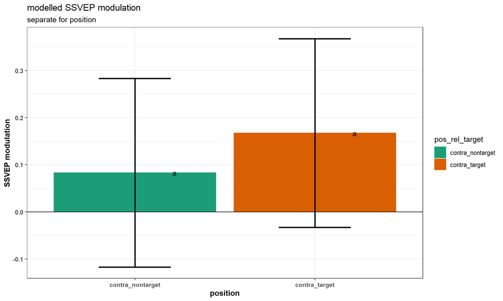

```r
CLD_obj = cld(anova_lsmeans_c,
          alpha=0.05,
          Letters=letters,      ### Use lower-case letters for .group
          adjust="holm")
CLD_obj$.group=gsub(" ", "", CLD_obj$.group)

ggplot(CLD_obj, aes(x = pos_rel_target, y = lsmean, color = pos_rel_target, fill = pos_rel_target, label = .group)) +
  stat_summary(fun.data = mean_se, geom = "bar", position = "dodge") +
  geom_hline(yintercept=0, show.legend = FALSE) +
  geom_errorbar(aes(ymin = asymp.LCL, ymax = asymp.UCL), width=.4, size=.9, position = position_dodge(0.4),color = "black") +
  theme_bw() +
  theme(axis.title = element_text(face = "bold"), axis.text = element_text(face = "bold"),plot.caption = element_text(hjust = 0)) +
  ylab("SSVEP modulation") +
  ggtitle("modelled SSVEP modulation",
           subtitle="separate for position") +
  scale_x_discrete("position") +
  # labs(caption  = paste0("\nMeans sharing a letter are ",
  #                        "not significantly different.",
  #                        "(holm corrected comparisons)."), hjust=0.5) +
 geom_text(nudge_x = c(+0.22), color   = "black") +
  scale_fill_brewer(palette = "Dark2")+
  scale_color_brewer(palette = "Dark2")
```

```r
## Validiaet X Seite
anova_lsmeans_c <- lsmeans(model2test, c("pos_rel_target","cue_validity_label"))
```

[output not shown]

[output not shown]